# Tidymodels Template

Patrick Ward

12/10/2021

The aim of this template is to provide a step-by-step approach to model building within the `tidymodels` framework. It is not meant to be exhaustive as `tidymodels` is extensive with respect to its functionality and the types of models that can be fit.

### Resources

**Tidymodels homepage:** https://www.tidymodels.org/ **Tidy Modeling with R:** https://www.tmwr.org/ **ISLR tidymodels labs:** https://emilhvitfeldt.github.io/ISLR-tidymodels-labs/index.html

## Load Packages & Data

```r
library(tidyverse)
library(tidymodels)
df <- mtcars
df %>% head()
```

```
##                    mpg cyl disp  hp drat    wt  qsec vs am gear carb
## Mazda RX4         21.0   6  160 110 3.90 2.620 16.46  0  1    4    4
## Mazda RX4 Wag     21.0   6  160 110 3.90 2.875 17.02  0  1    4    4
## Datsun 710        22.8   4  108  93 3.85 2.320 18.61  1  1    4    1
## Hornet 4 Drive    21.4   6  258 110 3.08 3.215 19.44  1  0    3    1
## Hornet Sportabout 18.7   8  360 175 3.15 3.440 17.02  0  0    3    2
## Valiant           18.1   6  225 105 2.76 3.460 20.22  1  0    3    1
```

```r
## Create some missing values so that the data will require pre-processing when you create your model recipe

df[8, 4] <- NA
df[c(20, 3) ,6] <- NA
df[c(27, 10), 7] <- NA
```

**NOTE: Prior to splitting data and moving into the model building process, you would commonly perform exploratory data analysis here to acquaint yourself with the data.**

## Split Data

**Train/Test Split**

Create your train and test splits so that you can hold a portion of the data out, to officially test the model once the final model has been built.

```r
set.seed(3333)
car_split <- initial_split(mtcars)
car_split
```

```
## <Analysis/Assess/Total>
## <24/8/32>
```

```r
train <- training(car_split)
test <- testing(car_split)
```

**Cross Validation**

We can further split our training data into cross validation folds to fit the model to a portion of the training data and then test it on a holdout set, repeating this process `k` number of times.

```r
set.seed(34)
cv_folds <- vfold_cv(
  data = train,
  v = 5
  )

cv_folds
```

```
## #  5-fold cross-validation
## # A tibble: 5 × 2
##   splits         id
##   <list>         <chr>
## 1 <split [19/5]> Fold1
## 2 <split [19/5]> Fold2
## 3 <split [19/5]> Fold3
## 4 <split [19/5]> Fold4
## 5 <split [20/4]> Fold5
```

## Model Specification

Here we can specify one or many models that we might be interested in fitting.

```r
## linear regression
lm_spec <- linear_reg() %>%
  set_engine("lm") %>%
  set_mode("regression")

## random forest
rf_spec <-
  rand_forest(
    mtry = tune()
    ) %>%
  set_mode("regression") %>%
  set_engine("randomForest", importance = TRUE)
```

## Recipe

The recipe is where you tell `tidymodels` how you want to handle the data:

- Which features you want to use
- How to pre-process those features
- And do any extra feature engineering

All 75 `step_` functions for pre-processing and feature engineering can be searched found here: **https://www.tidymodels.org/find/recipes/**

```r
## create a lnear model and impute the median for all NA values in predictor variables
car_rec <-
  recipe(disp ~ hp + drat + wt + qsec,
                  data = train) %>%
  step_impute_median(all_numeric_predictors())

# Look at the steps that were performed in the recipe
car_rec %>%
  prep()
```

```
## Data Recipe
##
## Inputs:
##
##       role #variables
##    outcome          1
##  predictor          4
##
## Training data contained 24 data points and no missing data.
##
## Operations:
##
## Median Imputation for hp, drat, wt, qsec [trained]
```

```r
## See how the steps effected the train data
car_rec %>%
  prep() %>%
  bake(new_data = NULL)
```

```
## # A tibble: 24 × 5
##       hp  drat    wt  qsec  disp
##    <dbl> <dbl> <dbl> <dbl> <dbl>
##  1    91  4.43  2.14  16.7 120.
##  2    97  3.7   2.46  20.0 120.
##  3   123  3.92  3.44  18.9 168.
##  4   109  4.11  2.78  18.6 121
##  5    93  3.85  2.32  18.6 108
##  6   113  3.77  1.51  16.9  95.1
##  7   264  4.22  3.17  14.5 351
##  8   245  3.73  3.84  15.4 350
##  9   175  3.15  3.44  17.0 360
## 10   205  2.93  5.25  18.0 472
## # … with 14 more rows
```

```r
## See how the steps effected the test data
car_rec %>%
  prep() %>%
  bake(new_data = test)
```

```
## # A tibble: 8 × 5
##      hp  drat    wt  qsec  disp
##   <dbl> <dbl> <dbl> <dbl> <dbl>
## 1   110  3.08  3.22  19.4 258
## 2   245  3.21  3.57  15.8 360
## 3   123  3.92  3.44  18.3 168.
## 4   180  3.07  4.07  17.4 276.
## 5   180  3.07  3.73  17.6 276.
## 6    52  4.93  1.62  18.5  75.7
## 7   175  3.08  3.84  17.0 400
## 8   175  3.62  2.77  15.5 145
```

## Workflow/Workflow Sets

- If you are only fitting one model then you only need a single `workflow`
- If you are fitting more than one model, simultaneously, then you can use a `workflowset`

I’ll show both options below.

**Create a single workflow**

```r
lm_wf <- workflow() %>%
  add_recipe(car_rec) %>%
  add_model(lm_spec)

lm_wf
```

```
## ══ Workflow ════════════════════════════════════════════════════════════════════
## Preprocessor: Recipe
## Model: linear_reg()
##
## ── Preprocessor ────────────────────────────────────────────────────────────────
## 1 Recipe Step
##
## • step_impute_median()
##
## ── Model ───────────────────────────────────────────────────────────────────────
## Linear Regression Model Specification (regression)
##
## Computational engine: lm
```

**Create a workflow set for multiple models**

```r
reg_wfs <-
  workflow_set(
    preproc = list(car_rec),
    models = list(lm_spec, rf_spec),
    cross = TRUE
  )

reg_wfs
```

```
## # A workflow set/tibble: 2 × 4
##   wflow_id           info             option    result
##   <chr>              <list>           <list>    <list>
## 1 recipe_linear_reg  <tibble [1 × 4]> <opts[0]> <list [0]>
## 2 recipe_rand_forest <tibble [1 × 4]> <opts[0]> <list [0]>
```

## Fit Model on Training Data

**Fit workflow to CV-Folds**

```r
car_lm <- lm_wf %>%
  fit_resamples(
    resamples = cv_folds
  )

car_lm
```

```
## # Resampling results
## # 5-fold cross-validation
## # A tibble: 5 × 4
##   splits         id    .metrics         .notes
##   <list>         <chr> <list>           <list>
## 1 <split [19/5]> Fold1 <tibble [2 × 4]> <tibble [0 × 1]>
## 2 <split [19/5]> Fold2 <tibble [2 × 4]> <tibble [0 × 1]>
## 3 <split [19/5]> Fold3 <tibble [2 × 4]> <tibble [0 × 1]>
## 4 <split [19/5]> Fold4 <tibble [2 × 4]> <tibble [0 × 1]>
## 5 <split [20/4]> Fold5 <tibble [2 × 4]> <tibble [0 × 1]>
```

**Tune the random forest in the workflow set to the CV-folds**

```r
doParallel::registerDoParallel(cores = 5)

car_wfs <-
  reg_wfs %>%
  workflow_map(
    seed = 67,
    fn = "tune_grid",
    grid = 10, # params to pass to tune grid
    resamples = cv_folds
  )
```

```
## i Creating pre-processing data to finalize unknown parameter: mtry
```

```r
doParallel::stopImplicitCluster()

car_wfs
```

```
## # A workflow set/tibble: 2 × 4
##   wflow_id           info             option    result
##   <chr>              <list>           <list>    <list>
## 1 recipe_linear_reg  <tibble [1 × 4]> <opts[2]> <rsmp[+]>
## 2 recipe_rand_forest <tibble [1 × 4]> <opts[2]> <tune[+]>
```

```r
### If there was no tuning that needed to take plate remove the fn and grid arguments
# car_wfs <- workflow_map(
#     reg_wfs,
#     "fit_resamples",
#     resamples = cv_folds,
#     seed = 67
#   )
```

## Evaluate Model Outputs

**single workflow**

```r
collect_metrics(car_lm)
```

```
## # A tibble: 2 × 6
##   .metric .estimator   mean     n std_err .config
##   <chr>   <chr>       <dbl> <int>   <dbl> <chr>
## 1 rmse    standard   40.9       5 10.1    Preprocessor1_Model1
## 2 rsq     standard    0.874     5  0.0608 Preprocessor1_Model1
```

**workflow set**

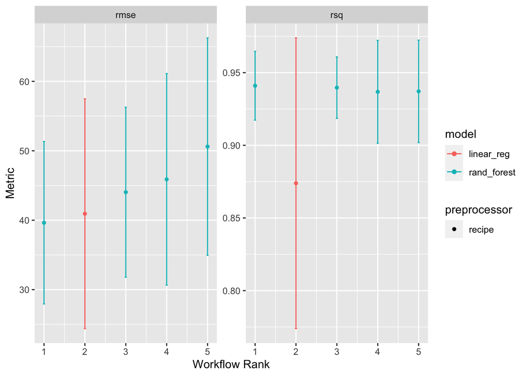

```r
autoplot(car_wfs)
```

```r
collect_metrics(car_wfs)
```

```
## # A tibble: 10 × 9
##    wflow_id    .config    preproc model  .metric .estimator   mean     n std_err
##    <chr>       <chr>      <chr>   <chr>  <chr>   <chr>       <dbl> <int>   <dbl>
##  1 recipe_lin… Preproces… recipe  linea… rmse    standard   40.9       5 10.1
##  2 recipe_lin… Preproces… recipe  linea… rsq     standard    0.874     5  0.0608
##  3 recipe_ran… Preproces… recipe  rand_… rmse    standard   50.6       5  9.52
##  4 recipe_ran… Preproces… recipe  rand_… rsq     standard    0.937     5  0.0214
##  5 recipe_ran… Preproces… recipe  rand_… rmse    standard   45.9       5  9.26
##  6 recipe_ran… Preproces… recipe  rand_… rsq     standard    0.937     5  0.0215
##  7 recipe_ran… Preproces… recipe  rand_… rmse    standard   44.0       5  7.44
##  8 recipe_ran… Preproces… recipe  rand_… rsq     standard    0.940     5  0.0129
##  9 recipe_ran… Preproces… recipe  rand_… rmse    standard   39.6       5  7.11
## 10 recipe_ran… Preproces… recipe  rand_… rsq     standard    0.941     5  0.0144
```

```r
rank_results(car_wfs, rank_metric = "rmse", select_best = TRUE)
```

```
## # A tibble: 4 × 9
##   wflow_id    .config     .metric   mean std_err     n preprocessor model   rank
##   <chr>       <chr>       <chr>    <dbl>   <dbl> <int> <chr>        <chr>  <int>
## 1 recipe_ran… Preprocess… rmse    39.6    7.11       5 recipe       rand_…     1
## 2 recipe_ran… Preprocess… rsq      0.941  0.0144     5 recipe       rand_…     1
## 3 recipe_lin… Preprocess… rmse    40.9   10.1        5 recipe       linea…     2
## 4 recipe_lin… Preprocess… rsq      0.874  0.0608     5 recipe       linea…     2
```

## Make Predictions on Test Data

**single workflow**

```r
single_wf_final <- lm_wf %>%
  last_fit(
    split = car_split
  )

## see results
collect_metrics(single_wf_final)
```

```
## # A tibble: 2 × 4
##   .metric .estimator .estimate .config
##   <chr>   <chr>          <dbl> <chr>
## 1 rmse    standard      61.1   Preprocessor1_Model1
## 2 rsq     standard       0.686 Preprocessor1_Model1
```

```r
## see predictions
single_wf_final %>% collect_predictions()
```

```
## # A tibble: 8 × 5
##   id                .pred  .row  disp .config
##   <chr>             <dbl> <int> <dbl> <chr>
## 1 train/test split 220.       4 258   Preprocessor1_Model1
## 2 train/test split 338.       7 360   Preprocessor1_Model1
## 3 train/test split 221.      10 168.  Preprocessor1_Model1
## 4 train/test split 341.      12 276.  Preprocessor1_Model1
## 5 train/test split 311.      13 276.  Preprocessor1_Model1
## 6 train/test split   4.80    19  75.7 Preprocessor1_Model1
## 7 train/test split 327.      25 400   Preprocessor1_Model1
## 8 train/test split 241.      30 145   Preprocessor1_Model1
```

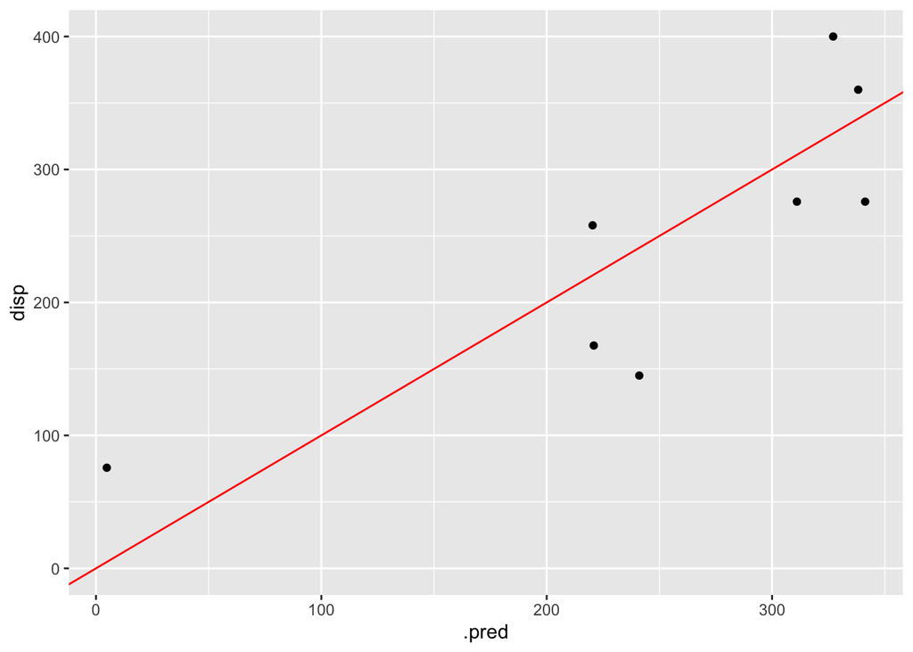

```r
## add predictions in to test set
test_pred_wf <- bind_cols(
  test,
  single_wf_final %>% collect_predictions() %>% dplyr::select(.pred))

test_pred_wf %>%
  ggplot(aes(x = .pred, y = disp)) +
  geom_point() +
  geom_abline(intercept = 0, slope = 1, color = "red") +
  expand_limits(y = 0)
```

**workflow set**

```r
## get the ID for the best fit model
wfs_best_id <- car_wfs %>%
  rank_results(
    rank_metric = "rmse",
    select_best = TRUE
  ) %>%
  slice(1) %>%
  pull(wflow_id)

wfs_best_id
```

```
## [1] "recipe_rand_forest"
```

```r
## Get the best workflowset
wf_best_fit <- extract_workflow(car_wfs, id = wfs_best_id)
wf_best_fit
```

```
## ══ Workflow ════════════════════════════════════════════════════════════════════
## Preprocessor: Recipe
## Model: rand_forest()
##
## ── Preprocessor ────────────────────────────────────────────────────────────────
## 1 Recipe Step
##
## • step_impute_median()
##
## ── Model ───────────────────────────────────────────────────────────────────────
## Random Forest Model Specification (regression)
##
## Main Arguments:
##   mtry = tune()
##
## Engine-Specific Arguments:
##   importance = TRUE
##
## Computational engine: randomForest
```

```r
## extract the tuned results from the best workflow
wf_best_tuned <- car_wfs[car_wfs$wflow_id == wfs_best_id,
                               "result"][[1]][[1]]

wf_best_tuned
```

```
## # Tuning results
## # 5-fold cross-validation
## # A tibble: 5 × 4
##   splits         id    .metrics         .notes
##   <list>         <chr> <list>           <list>
## 1 <split [19/5]> Fold1 <tibble [8 × 5]> <tibble [0 × 1]>
## 2 <split [19/5]> Fold2 <tibble [8 × 5]> <tibble [0 × 1]>
## 3 <split [19/5]> Fold3 <tibble [8 × 5]> <tibble [0 × 1]>
## 4 <split [19/5]> Fold4 <tibble [8 × 5]> <tibble [0 × 1]>
## 5 <split [20/4]> Fold5 <tibble [8 × 5]> <tibble [0 × 1]>
```

```r
collect_metrics(wf_best_tuned)
```

```
## # A tibble: 8 × 7
##    mtry .metric .estimator   mean     n std_err .config
##   <int> <chr>   <chr>       <dbl> <int>   <dbl> <chr>
## 1     1 rmse    standard   50.6       5  9.52   Preprocessor1_Model1
## 2     1 rsq     standard    0.937     5  0.0214 Preprocessor1_Model1
## 3     2 rmse    standard   45.9       5  9.26   Preprocessor1_Model2
## 4     2 rsq     standard    0.937     5  0.0215 Preprocessor1_Model2
## 5     3 rmse    standard   44.0       5  7.44   Preprocessor1_Model3
## 6     3 rsq     standard    0.940     5  0.0129 Preprocessor1_Model3
## 7     4 rmse    standard   39.6       5  7.11   Preprocessor1_Model4
## 8     4 rsq     standard    0.941     5  0.0144 Preprocessor1_Model4
```

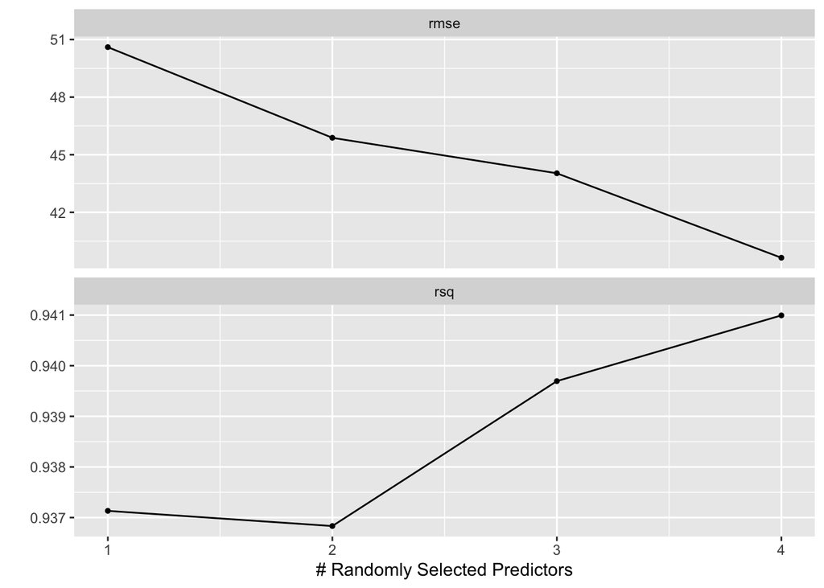

```r
autoplot(wf_best_tuned)
```

```r
select_best(wf_best_tuned, "rmse")
```

```
## # A tibble: 1 × 2
##    mtry .config
##   <int> <chr>
## 1     4 Preprocessor1_Model4
```

```r
## fit the final model
wf_best_final <- finalize_workflow(wf_best_fit, select_best(wf_best_tuned, "rmse"))

doParallel::registerDoParallel(cores = 5)

wf_best_final_fit <- wf_best_final %>%
  last_fit(
    split = car_split
  )

doParallel::stopImplicitCluster()

wf_best_final_fit
```

```
## # Resampling results
## # Manual resampling
## # A tibble: 1 × 6
##   splits         id               .metrics         .notes .predictions .workflow
##   <list>         <chr>            <list>           <list> <list>       <list>
## 1 <split [24/8]> train/test split <tibble [2 × 4]> <tibb… <tibble [8 … <workflo…
```

## Save Model Workflow for Future Deployment

**extract workflow & save**

```r
single_wf_model <- extract_workflow(single_wf_final)
single_wf_model
```

```
## ══ Workflow [trained] ══════════════════════════════════════════════════════════
## Preprocessor: Recipe
## Model: linear_reg()
##
## ── Preprocessor ────────────────────────────────────────────────────────────────
## 1 Recipe Step
##
## • step_impute_median()
##
## ── Model ───────────────────────────────────────────────────────────────────────
##
## Call:
## stats::lm(formula = ..y ~ ., data = data)
##
## Coefficients:
## (Intercept)           hp         drat           wt         qsec
##    388.6628       0.2817     -46.7834      79.6246     -16.0076
```

```r
save(single_wf_model, file = "single_wf_model.rda")
```

**extract workflow set**

```r
wfs_model <- extract_workflow(wf_best_final_fit)
wfs_model
```

```
## ══ Workflow [trained] ══════════════════════════════════════════════════════════
## Preprocessor: Recipe
## Model: rand_forest()
##
## ── Preprocessor ────────────────────────────────────────────────────────────────
## 1 Recipe Step
##
## • step_impute_median()
##
## ── Model ───────────────────────────────────────────────────────────────────────
##
## Call:
##  randomForest(x = maybe_data_frame(x), y = y, mtry = min_cols(~4L,      x), importance = ~TRUE)
##                Type of random forest: regression
##                      Number of trees: 500
## No. of variables tried at each split: 4
##
##           Mean of squared residuals: 1417.558
##                     % Var explained: 91.28
```

```r
save(wfs_model, file = "wfs_model.rda")
```

## Load Saved Model and Deploy Workflow on new data

**Create some fake data to predict on**

```r
new_dat <- tibble(
  hp = c(220, 86),
  drat = c(3.7, 2.2),
  wt = c(2.11, 1.72),
  qsec = c(15.9, 17.3)
)
```

**Load single workflow and fit to new data**

```r
load("single_wf_model.rda")
predict(single_wf_model, new_data = new_dat)
```

```
## # A tibble: 2 × 1
##   .pred
##   <dbl>
## 1  191.
## 2  170.
```

**Load workflow set and fit to new data**

```r
load("wfs_model.rda")
predict(wfs_model, new_data = new_dat)
```

```
## # A tibble: 2 × 1
##   .pred
##   <dbl>
## 1  326.
## 2  126.
```